# Project - Supervised Classifcation - Loan Modelling

## Build Decision Tree Model

- We will build a model using the DecisionTreeClassifier function. Using default 'gini' criteria to split.
- If the frequency of class A (Personal Loan:1) is 9% and the frequency of class B (Personal Loan:0) is 91%, then class B will become the dominant class and the decision tree will become biased toward the dominant classes.
- In this case, we can pass a dictionary {0:0.1,1:0.9} to the model to specify the weight of each class and the decision tree will give more weightage to class 1.
- class_weight is a hyperparameter for the decision tree classifier.

```python
# Libraries to build decision tree classifier
from sklearn.tree import DecisionTreeClassifier
from sklearn import tree

# To tune different models
from sklearn.model_selection import GridSearchCV

# To get diferent metric scores
from sklearn.metrics import (
    make_scorer
)
```

```python
model = DecisionTreeClassifier(
    criterion="gini", class_weight={0: 0.10, 1: 0.90}, random_state=1
)
```

```python
model.fit(X_train, y_train)
```

```
DecisionTreeClassifier(class_weight={0: 0.1, 1: 0.9}, random_state=1)
```

#### Create functions to calculate different metrics and confusion matrix so that we don't have to use the same code repeatedly for each model.

- The get_recall_score function will be used to check the model performance of decision tree models.
- The make_confusion_matrix function will be used to plot confusion matrix.

```python
##  Function to calculate recall score
def get_recall_score(model, predictors, target):
    """
    model: classifier
    predictors: independent variables
    target: dependent variable

    """
    prediction = model.predict(predictors)
    return recall_score(target, prediction)
```

```python
def confusion_matrix_sklearn(model, predictors, target):
    """
    To plot the confusion_matrix with percentages

    model: classifier
    predictors: independent variables
    target: dependent variable
    """
    y_pred = model.predict(predictors)
    cm = confusion_matrix(target, y_pred)
    labels = np.asarray(
        [
            ["{0:0.0f}".format(item) + "\n{0:.2%}".format(item / cm.flatten().sum())]
            for item in cm.flatten()
        ]
    ).reshape(2, 2)

    plt.figure(figsize=(6, 4))
    sns.heatmap(cm, annot=labels, fmt="")
    plt.ylabel("True label")
    plt.xlabel("Predicted label")
```

#### Checking model performance on Training set

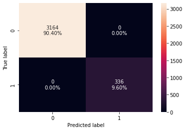

```python
confusion_matrix_sklearn(model, X_train, y_train)
```

```python
decision_tree_perf_train = get_recall_score(model, X_train, y_train)
print("Recall Score:", decision_tree_perf_train)
```

```
Recall Score: 1.0
```

> **Observations**:
> - As predicted with default paramters, Model is able to perfectly classify all the data points on the training set.
> - 0 errors on the training set, each sample has been classified correctly.
> - As we know a decision tree will continue to grow and classify each data point correctly if no restrictions are applied as the trees will learn all the patterns in the training set.
> - This generally leads to overfitting of the model as Decision Tree will perform well on the training set but will fail to replicate the performance on the test set.

#### Checking model performance on Test set

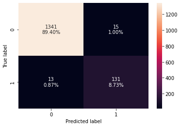

```python
confusion_matrix_sklearn(model, X_test, y_test)
```

```python
decision_tree_perf_test = get_recall_score(model, X_test, y_test)
print("Recall Score:", decision_tree_perf_test)
```

```
Recall Score: 0.9097222222222222
```

> **Observations**:
> - Recall score for the test set is not bad but there may be improvement oppertunities

## Visualizing the Decision Tree

```python
## creating a list of column names
feature_names = X_train.columns.to_list()
```

```python
# Write a function to plot tree with some custom arguments so that this code can be reused later
def plot_tree(model, feature_names, figsize=(15,10), fontsize=12):
    """
    Plots a tree from a Decision Tree model and features.
    """
    plt.figure(figsize=figsize)
    out = tree.plot_tree(
        model,
        feature_names=feature_names,
        filled=True,
        fontsize=fontsize,
        node_ids=False,
        rounded=True,
        class_names=None,
    )
    # below code will add arrows to the decision tree split if they are missing
    for o in out:
        arrow = o.arrow_patch
        if arrow is not None:
            arrow.set_edgecolor("black")
            arrow.set_linewidth(1)
    plt.show()
```

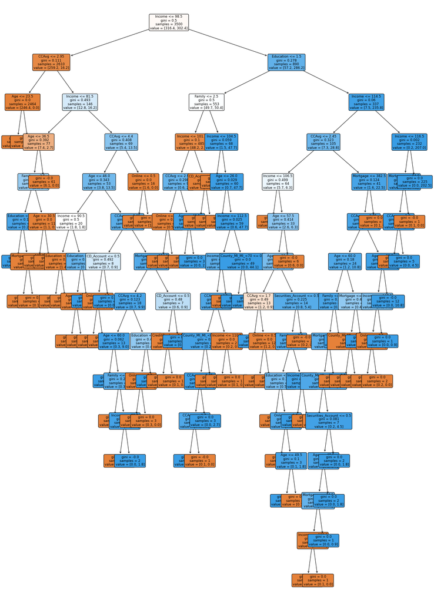

```python
plot_tree(model, feature_names, figsize=(20,30), fontsize=9)
```

```python
# Text report showing the rules of a decision tree -
print(tree.export_text(model, feature_names=feature_names, show_weights=True))
```

```
|--- Income <= 98.50
|   |--- CCAvg <= 2.95
|   |   |--- Age <= 23.50
|   |   |   |--- weights: [0.90, 0.00] class: 0
|   |   |--- Age >  23.50
|   |   |   |--- weights: [245.50, 0.00] class: 0
|   |--- CCAvg >  2.95
|   |   |--- Income <= 81.50
|   |   |   |--- Age <= 36.50
|   |   |   |   |--- Family <= 3.50
|   |   |   |   |   |--- Education <= 2.50
|   |   |   |   |   |   |--- weights: [0.00, 2.70] class: 1
|   |   |   |   |   |--- Education >  2.50
|   |   |   |   |   |   |--- Mortgage <= 195.50
|   |   |   |   |   |   |   |--- weights: [0.10, 0.00] class: 0
|   |   |   |   |   |   |--- Mortgage >  195.50
|   |   |   |   |   |   |   |--- weights: [0.10, 0.00] class: 0
|   |   |   |   |--- Family >  3.50
|   |   |   |   |   |--- Age <= 30.50
|   |   |   |   |   |   |--- weights: [0.20, 0.00] class: 0
|   |   |   |   |   |--- Age >  30.50
|   |   |   |   |   |   |--- weights: [0.90, 0.00] class: 0
|   |   |   |--- Age >  36.50
|   |   |   |   |--- weights: [6.10, 0.00] class: 0
|   |   |--- Income >  81.50
|   |   |   |--- CCAvg <= 4.40
|   |   |   |   |--- Age <= 46.00
|   |   |   |   |   |--- Income <= 90.50
|   |   |   |   |   |   |--- Education <= 1.50
|   |   |   |   |   |   |   |--- weights: [0.40, 0.00] class: 0
|   |   |   |   |   |   |--- Education >  1.50
|   |   |   |   |   |   |   |--- weights: [1.00, 0.00] class: 0
|   |   |   |   |   |--- Income >  90.50
|   |   |   |   |   |   |--- Education <= 1.50
|   |   |   |   |   |   |   |--- Age <= 28.50
|   |   |   |   |   |   |   |   |--- weights: [0.10, 0.00] class: 0
|   |   |   |   |   |   |   |--- Age >  28.50
|   |   |   |   |   |   |   |   |--- weights: [0.30, 0.00] class: 0
|   |   |   |   |   |   |--- Education >  1.50
|   |   |   |   |   |   |   |--- weights: [0.00, 1.80] class: 1
```

[output cut: 162 more lines]

```
|   |   |   |   |   |   |--- Age >  39.00
|   |   |   |   |   |   |   |--- weights: [0.00, 10.80] class: 1
|   |   |   |   |--- Mortgage >  382.50
|   |   |   |   |   |--- weights: [0.10, 0.00] class: 0
|   |   |--- Income >  114.50
|   |   |   |--- Income <= 116.50
|   |   |   |   |--- Mortgage <= 94.50
|   |   |   |   |   |--- CCAvg <= 1.00
|   |   |   |   |   |   |--- weights: [0.10, 0.00] class: 0
|   |   |   |   |   |--- CCAvg >  1.00
|   |   |   |   |   |   |--- weights: [0.00, 4.50] class: 1
|   |   |   |   |--- Mortgage >  94.50
|   |   |   |   |   |--- weights: [0.10, 0.00] class: 0
|   |   |   |--- Income >  116.50
|   |   |   |   |--- weights: [0.00, 202.50] class: 1
```

```python
# importance of features in the tree building ( The importance of a feature is computed as the
# (normalized) total reduction of the criterion brought by that feature. It is also known as the Gini importance )

imp_df1 = pd.DataFrame(
        model.feature_importances_, columns=["Imp"], index=X_train.columns
    ).sort_values(by="Imp", ascending=False)
imp_df1
```

|  | Imp |
| --- | --- |
| Income | 6.433457e-01 |
| Family | 1.421463e-01 |
| Education | 1.059453e-01 |
| CCAvg | 7.679903e-02 |
| Age | 1.656977e-02 |
| Mortgage | 6.451595e-03 |
| CD_Account | 4.874829e-03 |
| County_MI_MI_<70 | 1.671901e-03 |
| Securities_Account | 1.048091e-03 |
| County_MI_MI_<80 | 5.961448e-04 |
| Online | 5.514339e-04 |
| CreditCard | 2.584906e-18 |
| County_MI_MI_<60 | 1.292453e-18 |
| County_MI_MI_<50 | 0.000000e+00 |
| County_MI_MI_<90 | 0.000000e+00 |

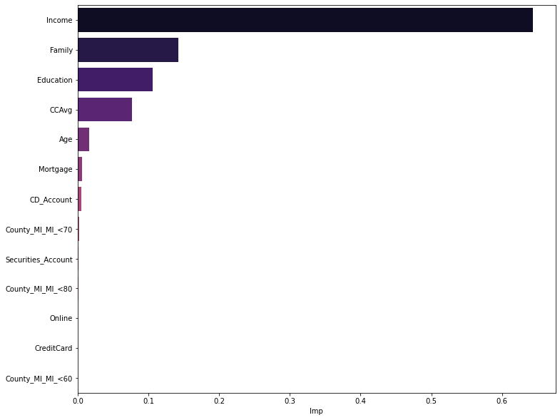

```python
# Let's see a plot with relative importance where importance is > 0
plt.figure(figsize=(12, 10))
data = imp_df1[imp_df1.Imp > 0]
sns.barplot(x=data.Imp, y=data.index, label="Relative Importance", palette="magma");
```

> **Observations**:
> - Decision Tree model has given very high importance to the Income feature
> - Family size, Education and CCAvg also carry high importance.
> - Age, Mortgage, CD_Account and Couties with median Income between 60K to 70K has some importance.
> - Other features have very low importance.

### Finding the best possible model with Pre Pruning

Althogh we got better recall score on test set than Logistic Regression with default Decision Tree parameters, but we would like to see if the model can be generalized more to get a better recall score with test dataset.

#### Using GridSearch for Hyperparameter tuning of our tree model

- Hyperparameter tuning is also tricky in the sense that there is no direct way to calculate how a change in the hyperparameter value will reduce the loss of your model, so we usually resort to experimentation. i.e we'll use Grid search
- Grid search is a tuning technique that attempts to compute the optimum values of hyperparameters.
- It is an exhaustive search that is performed on a the specific parameter values of a model.
- The parameters of the estimator/model used to apply these methods are optimized by cross-validated grid-search over a parameter grid.

```python
# Choose the type of classifier.
estimator = DecisionTreeClassifier(random_state=1, class_weight={0: 0.10, 1: 0.90})

# Grid of parameters to choose from
parameters = {
    "max_depth": [5, 10, 15, None],
    "criterion": ["entropy", "gini"],
    "splitter": ["best", "random"],
    "min_impurity_decrease": [0.00001, 0.0001, 0.01],
}

# Type of scoring used to compare parameter combinations
scorer = make_scorer(recall_score)

# Run the grid search
grid_obj = GridSearchCV(estimator, parameters, scoring=scorer, cv=5)
grid_obj = grid_obj.fit(X_train, y_train)

# Set the clf to the best combination of parameters
estimator = grid_obj.best_estimator_

# Fit the best algorithm to the data.
estimator.fit(X_train, y_train)
```

```
DecisionTreeClassifier(class_weight={0: 0.1, 1: 0.9}, max_depth=5,
                       min_impurity_decrease=0.01, random_state=1)
```

#### Checking performance on Training set

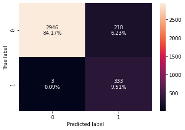

```python
confusion_matrix_sklearn(estimator, X_train, y_train)
```

```python
decision_tree_tune_perf_train = get_recall_score(estimator, X_train, y_train)
print("Recall Score:", decision_tree_tune_perf_train)
```

```
Recall Score: 0.9910714285714286
```

#### Checking performance on Test set

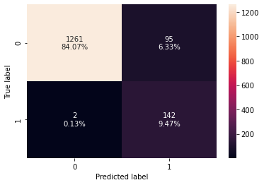

```python
confusion_matrix_sklearn(estimator, X_test, y_test)
```

```python
decision_tree_tune_perf_test = get_recall_score(estimator, X_test, y_test)
print("Recall Score:", decision_tree_tune_perf_test)
```

```
Recall Score: 0.9861111111111112
```

> **Observations**:
> - The model is giving a generalized result now.
> - Test recall score is around 0.986

## Visualizing the GV Optimized Decision Tree

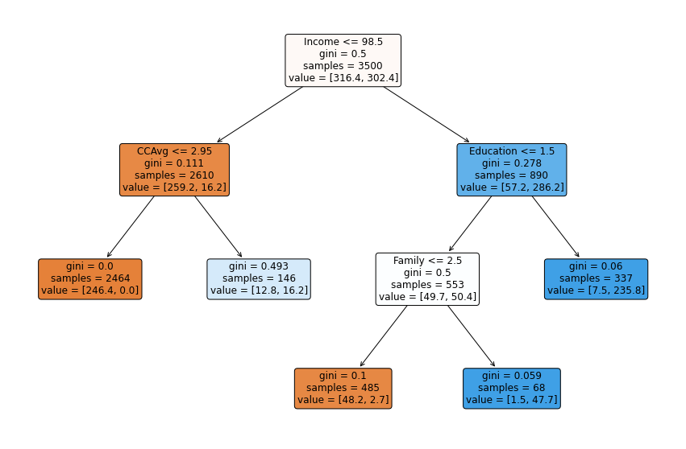

```python
plot_tree(estimator, feature_names)
```

```python
# Text report showing the rules of a decision tree -
print(tree.export_text(estimator, feature_names=feature_names, show_weights=True))
```

```
|--- Income <= 98.50
|   |--- CCAvg <= 2.95
|   |   |--- weights: [246.40, 0.00] class: 0
|   |--- CCAvg >  2.95
|   |   |--- weights: [12.80, 16.20] class: 1
|--- Income >  98.50
|   |--- Education <= 1.50
|   |   |--- Family <= 2.50
|   |   |   |--- weights: [48.20, 2.70] class: 0
|   |   |--- Family >  2.50
|   |   |   |--- weights: [1.50, 47.70] class: 1
|   |--- Education >  1.50
|   |   |--- weights: [7.50, 235.80] class: 1
```

```python
# importance of features in the tree building ( The importance of a feature is computed as the
# (normalized) total reduction of the 'criterion' brought by that feature. It is also known as the Gini importance )

imp_df2 =  pd.DataFrame(
        estimator.feature_importances_, columns=["Imp"], index=X_train.columns
    ).sort_values(by="Imp", ascending=False)

imp_df2
```

|  | Imp |
| --- | --- |
| Income | 0.673332 |
| Family | 0.154289 |
| Education | 0.112927 |
| CCAvg | 0.059451 |
| Age | 0.000000 |
| Mortgage | 0.000000 |
| Securities_Account | 0.000000 |
| CD_Account | 0.000000 |
| Online | 0.000000 |
| CreditCard | 0.000000 |
| County_MI_MI_<50 | 0.000000 |
| County_MI_MI_<60 | 0.000000 |
| County_MI_MI_<70 | 0.000000 |
| County_MI_MI_<80 | 0.000000 |
| County_MI_MI_<90 | 0.000000 |

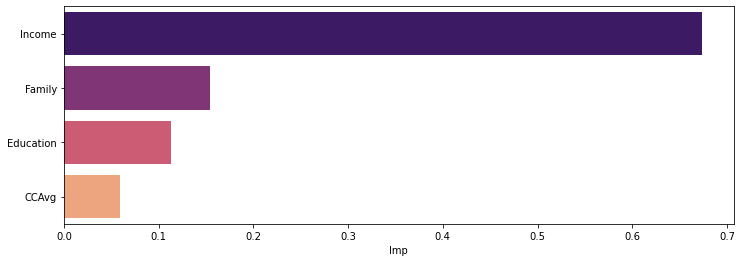

```python
# Let's see a plot with relative importance where importance is > 0
plt.figure(figsize=(12, 4))
data = imp_df2[imp_df2.Imp > 0]
sns.barplot(x=data.Imp, y=data.index, label="Relative Importance", palette="magma");
```

`So it seems customers having higher income, family size, higher education and higher monthly credit card usage will likely to buy a Personal Loan product.`

## Cost Complexity Pruning - Post Pruning

Although we have found a very good recall score with earlier Pre Pruned Tree but we need to see how the recall score changes with Post Pruning techniques.

The `DecisionTreeClassifier` provides parameters such as `min_samples_leaf` and `max_depth` to prevent a tree from overfiting. Cost complexity pruning provides another option to control the size of a tree. In `DecisionTreeClassifier`, this pruning technique is parameterized by the cost complexity parameter, `ccp_alpha`. Greater values of `ccp_alpha` increase the number of nodes pruned. Here we only show the effect of `ccp_alpha` on regularizing the trees and how to choose a `ccp_alpha` based on validation scores.

## Total impurity of leaves vs effective alphas of pruned tree

Minimal cost complexity pruning recursively finds the node with the "weakest link". The weakest link is characterized by an effective alpha, where the nodes with the smallest effective alpha are pruned first. To get an idea of what values of `ccp_alpha` could be appropriate, scikit-learn provides `DecisionTreeClassifier.cost_complexity_pruning_path` that returns the effective alphas and the corresponding total leaf impurities at each step of the pruning process. As alpha increases, more of the tree is pruned, which increases the total impurity of its leaves.

```python
clf = DecisionTreeClassifier(random_state=1, class_weight={0: 0.10, 1: 0.90})
path = clf.cost_complexity_pruning_path(X_train, y_train)
ccp_alphas, impurities = path.ccp_alphas, path.impurities
```

```python
pd.DataFrame(path)
```

|  | ccp_alphas | impurities |
| --- | --- | --- |
| 0 | 0.000000e+00 | -3.999171e-17 |
| 1 | 1.794155e-19 | -3.981230e-17 |
| 2 | 3.767725e-19 | -3.943552e-17 |
| 3 | 3.767725e-19 | -3.905875e-17 |
| 4 | 5.023634e-19 | -3.855639e-17 |
| 5 | 6.100127e-19 | -3.794638e-17 |
| 6 | 6.458957e-19 | -3.730048e-17 |
| 7 | 6.458957e-19 | -3.665458e-17 |
| 8 | 6.458957e-19 | -3.600869e-17 |
| 9 | 1.076493e-18 | -3.493220e-17 |
| 10 | 1.291791e-18 | -3.364040e-17 |
| 11 | 2.152986e-18 | -3.148742e-17 |
| 12 | 2.960356e-18 | -2.852706e-17 |
| 13 | 3.516544e-18 | -2.501052e-17 |
| 14 | 4.270089e-17 | 1.769037e-17 |
| 15 | 4.747334e-17 | 6.516370e-17 |
| 16 | 8.927715e-17 | 1.544408e-16 |
| 17 | 8.620555e-15 | 8.774996e-15 |
| 18 | 1.572355e-04 | 3.144709e-04 |
| 19 | 2.063018e-04 | 9.333764e-04 |
| 20 | 2.152628e-04 | 1.579165e-03 |
| 21 | 2.908856e-04 | 2.160936e-03 |
| 22 | 2.979198e-04 | 2.458856e-03 |
| 23 | 3.061954e-04 | 2.765051e-03 |
| 24 | 3.116631e-04 | 3.076714e-03 |
| 25 | 3.144709e-04 | 3.391185e-03 |
| 26 | 3.160726e-04 | 4.023330e-03 |
| 27 | 4.043329e-04 | 5.640662e-03 |
| 28 | 4.245357e-04 | 6.489733e-03 |
| 29 | 4.676746e-04 | 1.069880e-02 |
| 30 | 5.067039e-04 | 1.120551e-02 |
| 31 | 5.873481e-04 | 1.238020e-02 |
| 32 | 6.018322e-04 | 1.298204e-02 |
| 33 | 8.186118e-04 | 1.461926e-02 |
| 34 | 8.850980e-04 | 1.638946e-02 |
| 35 | 1.057766e-03 | 1.744722e-02 |
| 36 | 1.232143e-03 | 2.114365e-02 |
| 37 | 1.274986e-03 | 2.241864e-02 |
| 38 | 1.502935e-03 | 2.542451e-02 |
| 39 | 2.234302e-03 | 2.765881e-02 |
| 40 | 2.470563e-03 | 3.012937e-02 |
| 41 | 2.882434e-03 | 3.301181e-02 |
| 42 | 3.557588e-03 | 3.656939e-02 |
| 43 | 3.723499e-03 | 4.029289e-02 |
| 44 | 4.173757e-03 | 4.864041e-02 |
| 45 | 4.250110e-03 | 5.289052e-02 |
| 46 | 6.677017e-03 | 5.956753e-02 |
| 47 | 2.616908e-02 | 8.573662e-02 |
| 48 | 5.881120e-02 | 2.033590e-01 |
| 49 | 2.963851e-01 | 4.997441e-01 |

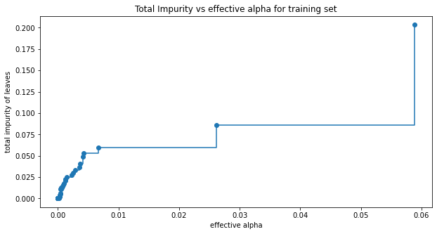

```python
fig, ax = plt.subplots(figsize=(10, 5))
ax.plot(ccp_alphas[:-1], impurities[:-1], marker="o", drawstyle="steps-post")
ax.set_xlabel("effective alpha")
ax.set_ylabel("total impurity of leaves")
ax.set_title("Total Impurity vs effective alpha for training set")
plt.show()
```

Next, we train a decision tree using the effective alphas. The last value in `ccp_alphas` is the alpha value that prunes the whole tree, leaving the tree, `clfs[-1]`, with one node.

```python
clfs = []
for ccp_alpha in ccp_alphas:
    clf = DecisionTreeClassifier(
        random_state=1, ccp_alpha=ccp_alpha, class_weight={0: 0.10, 1: 0.90}
    )
    clf.fit(X_train, y_train)
    clfs.append(clf)
print(
    "Number of nodes in the last tree is: {} with ccp_alpha: {}".format(
        clfs[-1].tree_.node_count, ccp_alphas[-1]
    )
)
```

```
Number of nodes in the last tree is: 1 with ccp_alpha: 0.2963850571088805
```

For the remainder, we remove the last element in `clfs` and `ccp_alphas`, because it is the trivial tree with only one node. Here we show that the number of nodes and tree depth decreases as alpha increases.

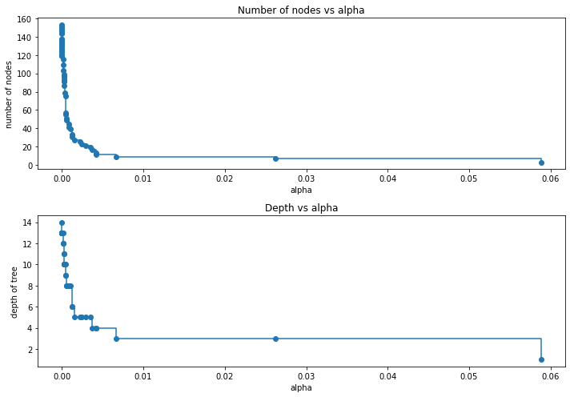

```python
clfs = clfs[:-1]
ccp_alphas = ccp_alphas[:-1]

node_counts = [clf.tree_.node_count for clf in clfs]
depth = [clf.tree_.max_depth for clf in clfs]
fig, ax = plt.subplots(2, 1, figsize=(10, 7))
ax[0].plot(ccp_alphas, node_counts, marker="o", drawstyle="steps-post")
ax[0].set_xlabel("alpha")
ax[0].set_ylabel("number of nodes")
ax[0].set_title("Number of nodes vs alpha")
ax[1].plot(ccp_alphas, depth, marker="o", drawstyle="steps-post")
ax[1].set_xlabel("alpha")
ax[1].set_ylabel("depth of tree")
ax[1].set_title("Depth vs alpha")
fig.tight_layout()
```

```python
recall_train = []
for clf in clfs:
    pred_train = clf.predict(X_train)
    values_train = recall_score(y_train, pred_train)
    recall_train.append(values_train)
```

```python
recall_test = []
for clf in clfs:
    pred_test = clf.predict(X_test)
    values_test = recall_score(y_test, pred_test)
    recall_test.append(values_test)
```

```python
train_scores = [clf.score(X_train, y_train) for clf in clfs]
test_scores = [clf.score(X_test, y_test) for clf in clfs]
```

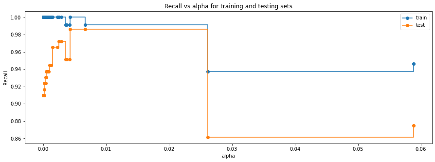

```python
fig, ax = plt.subplots(figsize=(15, 5))
ax.set_xlabel("alpha")
ax.set_ylabel("Recall")
ax.set_title("Recall vs alpha for training and testing sets")
ax.plot(
    ccp_alphas, recall_train, marker="o", label="train", drawstyle="steps-post",
)
ax.plot(ccp_alphas, recall_test, marker="o", label="test", drawstyle="steps-post")
ax.legend()
plt.show()
```

```python
# creating the model where we get highest train and test recall
index_best_model = np.argmax(recall_test)
best_model = clfs[index_best_model]
print(best_model)
```

```
DecisionTreeClassifier(ccp_alpha=0.004250110370594317,
                       class_weight={0: 0.1, 1: 0.9}, random_state=1)
```

```python
best_model.fit(X_train, y_train)
```

```
DecisionTreeClassifier(ccp_alpha=0.004250110370594317,
                       class_weight={0: 0.1, 1: 0.9}, random_state=1)
```

#### Check performance on Training set

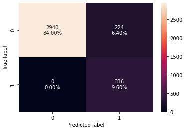

```python
confusion_matrix_sklearn(best_model, X_train, y_train)
```

```python
print("Recall Score:", get_recall_score(best_model, X_train, y_train))
```

```
Recall Score: 1.0
```

#### Check performance on Test set

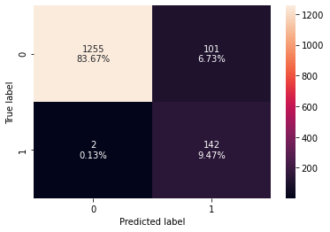

```python
confusion_matrix_sklearn(best_model, X_test, y_test)
```

```python
print("Recall Score:", get_recall_score(best_model, X_test, y_test))
```

```
Recall Score: 0.9861111111111112
```

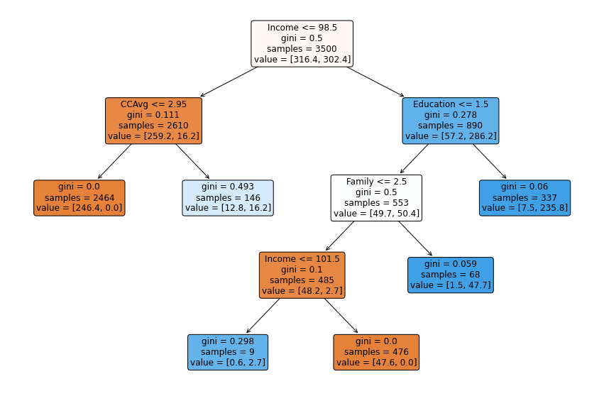

```python
plot_tree(best_model, feature_names)
```

```python
# importance of features in the tree building ( The importance of a feature is computed as the
# (normalized) total reduction of the criterion brought by that feature. It is also known as the Gini importance )

imp_df3 = pd.DataFrame(
        best_model.feature_importances_, columns=["Imp"], index=X_train.columns
    ).sort_values(by="Imp", ascending=False)
imp_df3
```

|  | Imp |
| --- | --- |
| Income | 0.678213 |
| Family | 0.151984 |
| Education | 0.111240 |
| CCAvg | 0.058563 |
| Age | 0.000000 |
| Mortgage | 0.000000 |
| Securities_Account | 0.000000 |
| CD_Account | 0.000000 |
| Online | 0.000000 |
| CreditCard | 0.000000 |
| County_MI_MI_<50 | 0.000000 |
| County_MI_MI_<60 | 0.000000 |
| County_MI_MI_<70 | 0.000000 |
| County_MI_MI_<80 | 0.000000 |
| County_MI_MI_<90 | 0.000000 |

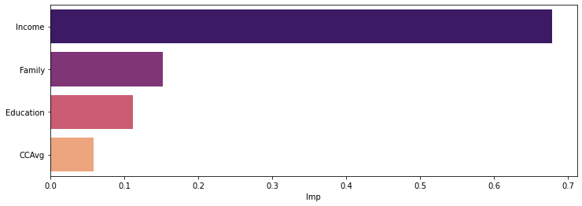

```python
plt.figure(figsize=(12, 4))
data = imp_df3[imp_df3.Imp > 0]
sns.barplot(x=data.Imp, y=data.index, label="Relative Importance", palette="magma");
```

Although we have achieved a very good recall score and it matches with pre-pruned tree but the training recall score is 1.0 which is a sign of little overfitting. For completeness we woulod check with a higher alpha to generalize the tree a bit more but making sure Recall score does not degrade.

From the **Recall vs alpha for training and testing sets** chart we see that recall score does not drop till about alpha = 0.025, hence we can go for a more generous alpha value and this will generalize the tree even more.

**Creating model with 0.025 ccp_alpha**

```python
best_model2 = DecisionTreeClassifier(
    ccp_alpha=0.025, class_weight={0: 0.10, 1: 0.90}, random_state=1
)
best_model2.fit(X_train, y_train)
```

```
DecisionTreeClassifier(ccp_alpha=0.025, class_weight={0: 0.1, 1: 0.9},
                       random_state=1)
```

#### Check performance on the Training set

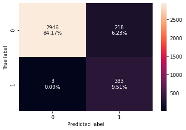

```python
confusion_matrix_sklearn(best_model2, X_train, y_train)
```

```python
decision_tree_postpruned_perf_train = get_recall_score(best_model2, X_train, y_train)
print("Recall Score:", decision_tree_postpruned_perf_train)
```

```
Recall Score: 0.9910714285714286
```

#### Check performance on the Test set

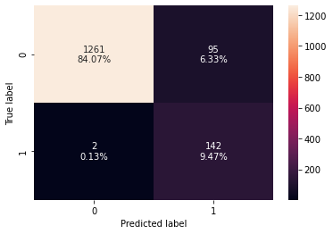

```python
confusion_matrix_sklearn(best_model2, X_test, y_test)
```

```python
decision_tree_postpruned_perf_test = get_recall_score(best_model2, X_test, y_test)
print("Recall Score:", decision_tree_postpruned_perf_test)
```

```
Recall Score: 0.9861111111111112
```

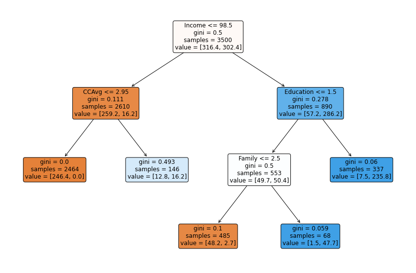

```python
plot_tree(best_model2, feature_names)
```

```python
# Text report showing the rules of a decision tree -
print(tree.export_text(best_model2, feature_names=feature_names, show_weights=True))
```

```
|--- Income <= 98.50
|   |--- CCAvg <= 2.95
|   |   |--- weights: [246.40, 0.00] class: 0
|   |--- CCAvg >  2.95
|   |   |--- weights: [12.80, 16.20] class: 1
|--- Income >  98.50
|   |--- Education <= 1.50
|   |   |--- Family <= 2.50
|   |   |   |--- weights: [48.20, 2.70] class: 0
|   |   |--- Family >  2.50
|   |   |   |--- weights: [1.50, 47.70] class: 1
|   |--- Education >  1.50
|   |   |--- weights: [7.50, 235.80] class: 1
```

```python
# importance of features in the tree building ( The importance of a feature is computed as the
# (normalized) total reduction of the 'criterion' brought by that feature. It is also known as the Gini importance )
imp_df4 = pd.DataFrame(
        best_model2.feature_importances_, columns=["Imp"], index=X_train.columns
    ).sort_values(by="Imp", ascending=False)

imp_df4
```

|  | Imp |
| --- | --- |
| Income | 0.673332 |
| Family | 0.154289 |
| Education | 0.112927 |
| CCAvg | 0.059451 |
| Age | 0.000000 |
| Mortgage | 0.000000 |
| Securities_Account | 0.000000 |
| CD_Account | 0.000000 |
| Online | 0.000000 |
| CreditCard | 0.000000 |
| County_MI_MI_<50 | 0.000000 |
| County_MI_MI_<60 | 0.000000 |
| County_MI_MI_<70 | 0.000000 |
| County_MI_MI_<80 | 0.000000 |
| County_MI_MI_<90 | 0.000000 |

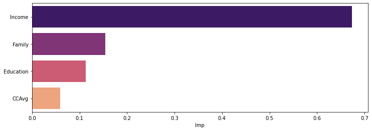

```python
plt.figure(figsize=(12, 4))
data = imp_df4[imp_df4.Imp > 0]
sns.barplot(x=data.Imp, y=data.index, label="Relative Importance", palette="magma");
```

> **Observations**:
- With ccp alpha 0.025 we are getting the same recall score with ccp alpha 0.004. But the tree is depth is less with alpha 0.025.
- Other observations related to feature importance remain same.
- With ccp alpha 0.025, the Decision Tree is same as the earlier Pre Pruned tree with max depth = 5.

### Comparing all the Decision Tree models

```python
# training performance comparison

models_train_comp_df = pd.DataFrame(
    [
        decision_tree_perf_train,
        decision_tree_tune_perf_train,
        decision_tree_postpruned_perf_train,
    ],
    index=['decision_tree_perf_train', 'decision_tree_prepruned_perf_train', 'decision_tree_postpruned_perf_train'],
    columns=["Recall on training set"]
)

print("Training performance comparison:")
models_train_comp_df
```

```
Training performance comparison:
```

|  | Recall on training set |
| --- | --- |
| decision_tree_perf_train | 1.000000 |
| decision_tree_prepruned_perf_train | 0.991071 |
| decision_tree_postpruned_perf_train | 0.991071 |

```python
# training performance comparison

models_test_comp_df = pd.DataFrame(
    [
        decision_tree_perf_test,
        decision_tree_tune_perf_test,
        decision_tree_postpruned_perf_test,
    ],
    index=['decision_tree_perf_test', 'decision_tree_prepruned_perf_test', 'decision_tree_postpruned_perf_test'],
    columns=["Recall on test set"]
)

print("Test performance comparison:")
models_test_comp_df
```

```
Test performance comparison:
```

|  | Recall on test set |
| --- | --- |
| decision_tree_perf_test | 0.909722 |
| decision_tree_prepruned_perf_test | 0.986111 |
| decision_tree_postpruned_perf_test | 0.986111 |

> **Observations**:
> - Pre Pruned Decision Tree has comparable Train and Test performance.
> - Post Pruned Decision Tree also has comparable Train and Test performance.
> - Pre Pruned Decision Tree and Post Pruned Decision Tree have same Recall score and tree depth and nodes.

### Conclusions

- We analyzed the data of AllLife's Bank Personal Loan campaign using both Logistic Regression models and Decision Tree Classifiers to build various predictive models to better understand the features that may have influenced the campaign result.
- Based on the business case we also decided that the Recall score should the performance criteria of our analysis, since we want to reduce the False Nagatives as oppertunity cost would be higher. In this case we are not very worried about the precision score since the cost of a campaign such as direct mail marketting or emails are not significant. Based on these analysis below conclusions can be drawn :-

> **Logisctic Regression**
- Logisctic Regression does not completely ignore features. Almost all features influnce the outcome but the degree of influence varies greatly.
- Out of all the featues if a customer is having CD_Account, higher Education, bigger Family, higher monthly CCAvg, higher income Income, Age, Mortgage then he/she is more likely to opt for a Personal Loan.
- On the other hand if a customer is having Credit cards with other banks, Securities accounts or uses Internet banking facilities then the probability of taking a Personal Loan decreses.
- Based on the customer location we can draw a conclusion that customers from counties having median income between 60K to 80K have a higher probablity of buying personal loan than other counties.

> **Decision Tree**
- Although there is some overlap in terms of conclusions but the Decision Tree gives a different perspective and ignores many features while predicting a Personal Loan customer.
- It gives the highest importance to Income. It clearly concludes that if a a cusomer has a higher income, he/she is more likely to go for a Personal Loan.
- It also gives weightage to bigger Family size, higher Education and higher monthly average Credit crad usage. Customers matching these criterions also have higher probability of buying personal loan products.
- Interestingly, Decision Tree does not give any importance to features other then Income, Family, Education and CCAvg.

### Recommendations

Based on the combined prediction results of both Logistic Regression and Decision Tree classification models and conclusions we offer below recommendations to AllLife Bank marketing department Personal Loan campaign.

- Internet research shows people take personal loans for covering cost of emergency expense, wedding, vacation, appliance purchase, home remodelling etc. Considering the repayment capability of a customer we should target high income range costomers first as this feature has come up in both types of models and from a bank perspective these will be safer investments.
- Cusotmers having CD accounts with the bank could also be likly canditates for Personal loans. As they would have some surity as well for paying back.
- Customers with bigger family size such 3 or 4 members, higher Education such as graduate or advanced degrees, higher monthly Credit card usage can be targetted next.
- Also customers having higher morgages, age and professional experience can be targetted for personal loans but the conversion rate may be low here.
- In order to increase the conversion rate further a personal loan social media campaing can be targetted to ZIP codes in counties where median income is between 60K to 80K per year. As analysis has shown people from these counties have higher probability of buying personal loans.
- If customers have credit cards from other banks and lower monthly average credit card usage then they have less probability of buying personal loans as they enjoy high borrowing power already. This type of customers should be targetted less unless other features recommend otherwise.

With above recommendations, derived from both Logistic Regression and Decision Tree models, we believe conversion rate of Personal Loan campaign will increase from the current rate of 9% to higher and AllLife Banks will be better equipped in converting its liability customers to personal loan customers (while retaining them as depositors).